# ch02_03_02B_02_Ticket_gender

## 타이타닉 생존자 예측 대회

### 학습 목표

- Ticket, Gender 피처를 사용한다.
- GridSearchCV를 통해 좋은 변수를 사용한다.
- 데이터 변환을 수행해 본다.
- 새로운 변수 생성을 알아본다.

### 목차

01. 데이터 불러오기  
02. 데이터 전처리  
03. 모델링  
04. 예측

## Data Fields

| 구분 | 설명 | 값 |
| --- | --- | --- |
| **Survival** | 생존 여부 | Survival. 0 = No, 1 = Yes |
| **Pclass** | 티켓의 클래스 | Ticket class. 1 = 1st, 2 = 2nd, 3 = 3rd |
| **Sex** | 성별(Sex) | 남(male)/여(female) |
| **Age** | 나이(Age in years.) |  |
| **SibSp** | 함께 탑승한 형제와 배우자의 수 /siblings, spouses aboard the Titanic. |  |
| **Parch** | 함께 탑승한 부모, 아이의 수 | # of parents / children aboard the Titanic. |
| **Ticket** | 티켓 번호(Ticket number) | (ex) CA 31352, A/5. 2151 |
| **Fare** | 탑승료(Passenger fare) |  |
| **Cabin** | 객실 번호(Cabin number) |  |
| **Embarked** | 탑승 항구(Port of Embarkation) | C = Cherbourg, Q = Queenstown, S = Southampton |

- siblings : 형제, 자매, 형제, 의붓 형제
- spouses : 남편, 아내 (정부와 약혼자는 무시)
- Parch : Parent(mother, father), child(daughter, son, stepdaughter, stepson)

### 01. 데이터 불러오기

목차로 이동하기

### 참고 노트북

- titanic 전체 노트북
  - https://www.kaggle.com/code/pliptor/how-am-i-doing-with-my-score/report
  - https://www.kaggle.com/code/pliptor/titanic-ticket-only-study/notebook

```python
import pandas as pd
import matplotlib.pyplot as plt
import seaborn as sns
import numpy as np
```

```python
sel_f = ['Ticket', 'Pclass', 'Sex']

train = pd.read_csv("data/titanic/train.csv",
                    usecols=['PassengerId', 'Survived']+sel_f)

test = pd.read_csv("data/titanic/test.csv",
                   usecols=['PassengerId'] + sel_f)

sub = pd.read_csv("data/titanic/gender_submission.csv")
```

```python
# 컬럼 추가 및 합치기
test['Survived'] = np.nan
all_df = pd.concat([train, test])
all_df.head()
```

|  | PassengerId | Survived | Pclass | Sex | Ticket |
| --- | --- | --- | --- | --- | --- |
| 0 | 1 | 0.0 | 3 | male | A/5 21171 |
| 1 | 2 | 1.0 | 1 | female | PC 17599 |
| 2 | 3 | 1.0 | 3 | female | STON/O2. 3101282 |
| 3 | 4 | 1.0 | 1 | female | 113803 |
| 4 | 5 | 0.0 | 3 | male | 373450 |

### 02. 티켓 변수 확인

목차로 이동하기

```python
all_df.Ticket.unique()
```

```
array(['A/5 21171', 'PC 17599', 'STON/O2. 3101282', '113803', '373450',
       '330877', '17463', '349909', '347742', '237736', 'PP 9549',
       '113783', 'A/5. 2151', '347082', '350406', '248706', '382652',
       '244373', '345763', '2649', '239865', '248698', '330923', '113788',
       '347077', '2631', '19950', '330959', '349216', 'PC 17601',
       'PC 17569', '335677', 'C.A. 24579', 'PC 17604', '113789', '2677',
       'A./5. 2152', '345764', '2651', '7546', '11668', '349253',
       'SC/Paris 2123', '330958', 'S.C./A.4. 23567', '370371', '14311',
       '2662', '349237', '3101295', 'A/4. 39886', 'PC 17572', '2926',
       '113509', '19947', 'C.A. 31026', '2697', 'C.A. 34651', 'CA 2144',
       '2669', '113572', '36973', '347088', 'PC 17605', '2661',
       'C.A. 29395', 'S.P. 3464', '3101281', '315151', 'C.A. 33111',
       'S.O.C. 14879', '2680', '1601', '348123', '349208', '374746',
       '248738', '364516', '345767', '345779', '330932', '113059',
       'SO/C 14885', '3101278', 'W./C. 6608', 'SOTON/OQ 392086', '343275',
       '343276', '347466', 'W.E.P. 5734', 'C.A. 2315', '364500', '374910',
       'PC 17754', 'PC 17759', '231919', '244367', '349245', '349215',
       '35281', '7540', '3101276', '349207', '343120', '312991', '349249',
       '371110', '110465', '2665', '324669', '4136', '2627',
       'STON/O 2. 3101294', '370369', 'PC 17558', 'A4. 54510', '27267',
       '370372', 'C 17369', '2668', '347061', '349241',
       'SOTON/O.Q. 3101307', 'A/5. 3337', '228414', 'C.A. 29178',
       'SC/PARIS 2133', '11752', '7534', 'PC 17593', '2678', '347081',
       'STON/O2. 3101279', '365222', '231945', 'C.A. 33112', '350043',
       '230080', '244310', 'S.O.P. 1166', '113776', 'A.5. 11206',
       'A/5. 851', 'Fa 265302', 'PC 17597', '35851', 'SOTON/OQ 392090',
       '315037', 'CA. 2343', '371362', 'C.A. 33595', '347068', '315093',
       '363291', '113505', 'PC 17318', '111240', 'STON/O 2. 3101280',
       '17764', '350404', '4133', 'PC 17595', '250653', 'LINE',
       'SC/PARIS 2131', '230136', '315153', '113767', '370365', '111428',
       '364849', '349247', '234604', '28424', '350046', 'PC 17610',
       '368703', '4579', '370370', '248747', '345770', '3101264', '2628',
       'A/5 3540', '347054', '2699', '367231', '112277',
       'SOTON/O.Q. 3101311', 'F.C.C. 13528', 'A/5 21174', '250646',
       '367229', '35273', 'STON/O2. 3101283', '243847', '11813',
       'W/C 14208', 'SOTON/OQ 392089', '220367', '21440', '349234',
       '19943', 'PP 4348', 'SW/PP 751', 'A/5 21173', '236171', '347067',
       '237442', 'C.A. 29566', 'W./C. 6609', '26707', 'C.A. 31921',
       '28665', 'SCO/W 1585', '367230', 'W./C. 14263',
       'STON/O 2. 3101275', '2694', '19928', '347071', '250649', '11751',
```

[output cut: 106 more lines]

```
       'C.A. 49867', 'A. 2. 39186', '315095', '368573', '2676',
       'SC 14888', 'CA 31352', 'W./C. 14260', '315085', '364859',
       'A/5 21175', 'SOTON/O.Q. 3101314', '2655', 'A/5 1478', 'PC 17607',
       '382650', '2652', '345771', '349202', '113801', '347467', '347079',
       '237735', '315092', '383123', '112901', '315091', '2658',
       'LP 1588', '368364', 'AQ/3. 30631', '28004', '350408', '347075',
       '2654', '244368', '113790', 'SOTON/O.Q. 3101309', '236854',
       'PC 17580', '2684', '349229', '110469', '244360', '2675', '2622',
       'C.A. 15185', '350403', '348125', '237670', '2688', '248726',
       'F.C.C. 13540', '113044', '1222', '368402', '315083', '112378',
       'SC/PARIS 2147', '28133', '248746', '315152', '29107', '680',
       '366713', '330910', 'SC/PARIS 2159', '349911', '244346', '364858',
       'C.A. 30769', '371109', '347065', '21332', '17765',
       'SC/PARIS 2166', '28666', '334915', '365237', '347086',
       'A.5. 3236', 'SOTON/O.Q. 3101262', '359309'], dtype=object)
```

- 티켓은 순전히 숫자인 것, 그리고 영숫자 접두사, 그리고 승무원인 LINE이 발행.

```python
all_df.loc[all_df['Ticket']=='LINE']
```

|  | PassengerId | Survived | Pclass | Sex | Ticket |
| --- | --- | --- | --- | --- | --- |
| 179 | 180 | 0.0 | 3 | male | LINE |
| 271 | 272 | 1.0 | 3 | male | LINE |
| 302 | 303 | 0.0 | 3 | male | LINE |
| 597 | 598 | 0.0 | 3 | male | LINE |

- 다른 데이터와 비슷하게 만들기 위해 LINE 0 으로 변경

```python
all_df['Ticket'] = all_df['Ticket'].replace('LINE', 'LINE 0')
all_df[all_df['Ticket']=='LINE 0']
```

|  | PassengerId | Survived | Pclass | Sex | Ticket |
| --- | --- | --- | --- | --- | --- |
| 179 | 180 | 0.0 | 3 | male | LINE 0 |
| 271 | 272 | 1.0 | 3 | male | LINE 0 |
| 302 | 303 | 0.0 | 3 | male | LINE 0 |
| 597 | 598 | 0.0 | 3 | male | LINE 0 |

### 티켓의 중복 확인

```python
dup_tickets = all_df.groupby('Ticket').size()
dup_tickets
```

```
Ticket
110152         3
110413         3
110465         2
110469         1
110489         1
              ..
W./C. 6608     5
W./C. 6609     1
W.E.P. 5734    2
W/C 14208      1
WE/P 5735      2
Length: 929, dtype: int64
```

### 중복 티켓 장수

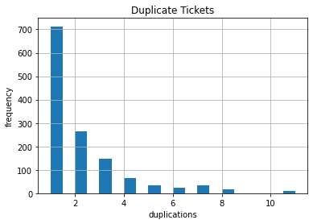

```python
all_df['중복티켓수'] = all_df['Ticket'].map(dup_tickets)
plt.xlabel('duplications')
plt.ylabel('frequency')
plt.title('Duplicate Tickets')
all_df['중복티켓수'].hist(bins=20)
```

- 유일한 티켓이 압도적으로 많다.

### 티켓의 값 처리

```python
all_df['Ticket'] = all_df['Ticket'].apply(lambda x: x.replace('.','').replace('/','').lower())
all_df.head()
```

|  | PassengerId | Survived | Pclass | Sex | Ticket | 중복티켓수 |
| --- | --- | --- | --- | --- | --- | --- |
| 0 | 1 | 0.0 | 3 | male | a5 21171 | 1 |
| 1 | 2 | 1.0 | 1 | female | pc 17599 | 2 |
| 2 | 3 | 1.0 | 3 | female | stono2 3101282 | 1 |
| 3 | 4 | 1.0 | 1 | female | 113803 | 2 |
| 4 | 5 | 0.0 | 3 | male | 373450 | 1 |

### Ticket의 값을 공백으로 분리 후, 앞의 이름을 갖는 변수 만들기

```python
"aaaaa 000000".split(' ')[0][0]    # 첫번째 단어의 맨 앞 첫글자
```

```
'a'
```

```python
def get_prefix(ticket):
    lead = ticket.split(' ')[0][0]

    # 알파벳인지 확인
    if lead.isalpha():
        return ticket.split(' ')[0]
    else:
        return 'NoPrefix'

all_df['Prefix'] = all_df['Ticket'].apply(lambda x: get_prefix(x))
all_df.head()
```

|  | PassengerId | Survived | Pclass | Sex | Ticket | 중복티켓수 | Prefix |
| --- | --- | --- | --- | --- | --- | --- | --- |
| 0 | 1 | 0.0 | 3 | male | a5 21171 | 1 | a5 |
| 1 | 2 | 1.0 | 1 | female | pc 17599 | 2 | pc |
| 2 | 3 | 1.0 | 3 | female | stono2 3101282 | 1 | stono2 |
| 3 | 4 | 1.0 | 1 | female | 113803 | 2 | NoPrefix |
| 4 | 5 | 0.0 | 3 | male | 373450 | 1 | NoPrefix |

```python
"a5 21171".split(' ')[-1]
```

```
'21171'
```

```python
str("a5 21171")[0]
```

```
'a'
```

```python
val = int( "a5 21171".split(' ')[-1] )
str(val)
```

```
'21171'
```

- TNumeric : 숫자로 변경
- TNlen : TNumeric의 길이
- LeadingDigit : TNumeric의 맨 앞글자
- TGroup : Ticket의 둿부분의 문자로 변경

```python
all_df['TNumeric'] = all_df['Ticket'].apply(lambda x: int(x.split(' ')[-1])//1)
all_df['TNlen'] = all_df['TNumeric'].apply(lambda x : len(str(x)))
all_df['LeadingDigit'] = all_df['TNumeric'].apply(lambda x : int(str(x)[0]))
all_df['TGroup'] = all_df['Ticket'].apply(lambda x: str(int(x.split(' ')[-1])//10))
all_df.head()
```

|  | PassengerId | Survived | Pclass | Sex | Ticket | 중복티켓수 | Prefix | TNumeric | TNlen | LeadingDigit | TGroup |
| --- | --- | --- | --- | --- | --- | --- | --- | --- | --- | --- | --- |
| 0 | 1 | 0.0 | 3 | male | a5 21171 | 1 | a5 | 21171 | 5 | 2 | 2117 |
| 1 | 2 | 1.0 | 1 | female | pc 17599 | 2 | pc | 17599 | 5 | 1 | 1759 |
| 2 | 3 | 1.0 | 3 | female | stono2 3101282 | 1 | stono2 | 3101282 | 7 | 3 | 310128 |
| 3 | 4 | 1.0 | 1 | female | 113803 | 2 | NoPrefix | 113803 | 6 | 1 | 11380 |
| 4 | 5 | 0.0 | 3 | male | 373450 | 1 | NoPrefix | 373450 | 6 | 3 | 37345 |

```python
pd.crosstab(all_df['Pclass'],all_df['LeadingDigit'])
```

| LeadingDigit Pclass | 0 | 1 | 2 | 3 | 4 | 5 | 6 | 7 | 8 | 9 |
| --- | --- | --- | --- | --- | --- | --- | --- | --- | --- | --- |
| 1 | 0 | 288 | 8 | 18 | 0 | 5 | 4 | 0 | 0 | 0 |
| 2 | 0 | 32 | 205 | 37 | 0 | 1 | 0 | 2 | 0 | 0 |
| 3 | 4 | 22 | 136 | 476 | 22 | 4 | 17 | 18 | 5 | 5 |

```python
all_df = all_df.drop(columns=['Ticket', 'TNumeric', 'Pclass'])
all_df
```

|  | PassengerId | Survived | Sex | 중복티켓수 | Prefix | TNlen | LeadingDigit | TGroup |
| --- | --- | --- | --- | --- | --- | --- | --- | --- |
| 0 | 1 | 0.0 | male | 1 | a5 | 5 | 2 | 2117 |
| 1 | 2 | 1.0 | female | 2 | pc | 5 | 1 | 1759 |
| 2 | 3 | 1.0 | female | 1 | stono2 | 7 | 3 | 310128 |
| 3 | 4 | 1.0 | female | 2 | NoPrefix | 6 | 1 | 11380 |
| 4 | 5 | 0.0 | male | 1 | NoPrefix | 6 | 3 | 37345 |
| ... | ... | ... | ... | ... | ... | ... | ... | ... |
| 413 | 1305 | NaN | male | 1 | a5 | 4 | 3 | 323 |
| 414 | 1306 | NaN | female | 3 | pc | 5 | 1 | 1775 |
| 415 | 1307 | NaN | male | 1 | sotonoq | 7 | 3 | 310126 |
| 416 | 1308 | NaN | male | 1 | NoPrefix | 6 | 3 | 35930 |
| 417 | 1309 | NaN | male | 3 | NoPrefix | 4 | 2 | 266 |

1309 rows × 8 columns

```python
all_df['Prefix']
```

```
0            a5
1            pc
2        stono2
3      NoPrefix
4      NoPrefix
         ...
413          a5
414          pc
415     sotonoq
416    NoPrefix
417    NoPrefix
Name: Prefix, Length: 1309, dtype: object
```

```python
all_df = pd.concat([pd.get_dummies(all_df[['Prefix','TGroup']]),
            all_df[['PassengerId','Survived','중복티켓수','TNlen','LeadingDigit', 'Sex']]],
            axis=1)

all_df
```

|  | Prefix_NoPrefix | Prefix_a | Prefix_a4 | Prefix_a5 | Prefix_aq3 | Prefix_aq4 | Prefix_as | Prefix_c | Prefix_ca | Prefix_casoton | ... | TGroup_847 | TGroup_85 | TGroup_923 | TGroup_954 | PassengerId | Survived | 중복티켓수 | TNlen | LeadingDigit | Sex |
| --- | --- | --- | --- | --- | --- | --- | --- | --- | --- | --- | --- | --- | --- | --- | --- | --- | --- | --- | --- | --- | --- |
| 0 | 0 | 0 | 0 | 1 | 0 | 0 | 0 | 0 | 0 | 0 | ... | 0 | 0 | 0 | 0 | 1 | 0.0 | 1 | 5 | 2 | male |
| 1 | 0 | 0 | 0 | 0 | 0 | 0 | 0 | 0 | 0 | 0 | ... | 0 | 0 | 0 | 0 | 2 | 1.0 | 2 | 5 | 1 | female |
| 2 | 0 | 0 | 0 | 0 | 0 | 0 | 0 | 0 | 0 | 0 | ... | 0 | 0 | 0 | 0 | 3 | 1.0 | 1 | 7 | 3 | female |
| 3 | 1 | 0 | 0 | 0 | 0 | 0 | 0 | 0 | 0 | 0 | ... | 0 | 0 | 0 | 0 | 4 | 1.0 | 2 | 6 | 1 | female |
| 4 | 1 | 0 | 0 | 0 | 0 | 0 | 0 | 0 | 0 | 0 | ... | 0 | 0 | 0 | 0 | 5 | 0.0 | 1 | 6 | 3 | male |
| ... | ... | ... | ... | ... | ... | ... | ... | ... | ... | ... | ... | ... | ... | ... | ... | ... | ... | ... | ... | ... | ... |
| 413 | 0 | 0 | 0 | 1 | 0 | 0 | 0 | 0 | 0 | 0 | ... | 0 | 0 | 0 | 0 | 1305 | NaN | 1 | 4 | 3 | male |
| 414 | 0 | 0 | 0 | 0 | 0 | 0 | 0 | 0 | 0 | 0 | ... | 0 | 0 | 0 | 0 | 1306 | NaN | 3 | 5 | 1 | female |
| 415 | 0 | 0 | 0 | 0 | 0 | 0 | 0 | 0 | 0 | 0 | ... | 0 | 0 | 0 | 0 | 1307 | NaN | 1 | 7 | 3 | male |
| 416 | 1 | 0 | 0 | 0 | 0 | 0 | 0 | 0 | 0 | 0 | ... | 0 | 0 | 0 | 0 | 1308 | NaN | 1 | 6 | 3 | male |
| 417 | 1 | 0 | 0 | 0 | 0 | 0 | 0 | 0 | 0 | 0 | ... | 0 | 0 | 0 | 0 | 1309 | NaN | 3 | 4 | 2 | male |

1309 rows × 451 columns

```python
dict_s = {'male':0, 'female':1}
all_df['Sex'] = all_df['Sex'].map(dict_s)
```

```python
predictors = sorted(list(set(all_df.columns) - set(['PassengerId','Survived'])))
predictors
```

```
['LeadingDigit',
 'Prefix_NoPrefix',
 'Prefix_a',
 'Prefix_a4',
 'Prefix_a5',
 'Prefix_aq3',
 'Prefix_aq4',
 'Prefix_as',
 'Prefix_c',
 'Prefix_ca',
 'Prefix_casoton',
 'Prefix_fa',
 'Prefix_fc',
 'Prefix_fcc',
 'Prefix_line',
 'Prefix_lp',
 'Prefix_pc',
 'Prefix_pp',
 'Prefix_ppp',
 'Prefix_sc',
 'Prefix_sca3',
 'Prefix_sca4',
 'Prefix_scah',
 'Prefix_scow',
 'Prefix_scparis',
 'Prefix_soc',
 'Prefix_sop',
 'Prefix_sopp',
 'Prefix_sotono2',
 'Prefix_sotonoq',
 'Prefix_sp',
 'Prefix_stono',
 'Prefix_stono2',
 'Prefix_stonoq',
 'Prefix_swpp',
 'Prefix_wc',
 'Prefix_wep',
 'Sex',
 'TGroup_0',
 'TGroup_1048',
```

[output cut: 394 more lines]

```
 'TGroup_69',
 'TGroup_707',
 'TGroup_726',
 'TGroup_75',
 'TGroup_753',
 'TGroup_754',
 'TGroup_755',
 'TGroup_759',
 'TGroup_793',
 'TGroup_847',
 'TGroup_85',
 'TGroup_923',
 'TGroup_954',
 'TNlen',
 '중복티켓수']
```

```python
all_df2 = all_df[predictors + ['Survived']]
all_df2.head()
```

|  | LeadingDigit | Prefix_NoPrefix | Prefix_a | Prefix_a4 | Prefix_a5 | Prefix_aq3 | Prefix_aq4 | Prefix_as | Prefix_c | Prefix_ca | ... | TGroup_755 | TGroup_759 | TGroup_793 | TGroup_847 | TGroup_85 | TGroup_923 | TGroup_954 | TNlen | 중복티켓수 | Survived |
| --- | --- | --- | --- | --- | --- | --- | --- | --- | --- | --- | --- | --- | --- | --- | --- | --- | --- | --- | --- | --- | --- |
| 0 | 2 | 0 | 0 | 0 | 1 | 0 | 0 | 0 | 0 | 0 | ... | 0 | 0 | 0 | 0 | 0 | 0 | 0 | 5 | 1 | 0.0 |
| 1 | 1 | 0 | 0 | 0 | 0 | 0 | 0 | 0 | 0 | 0 | ... | 0 | 0 | 0 | 0 | 0 | 0 | 0 | 5 | 2 | 1.0 |
| 2 | 3 | 0 | 0 | 0 | 0 | 0 | 0 | 0 | 0 | 0 | ... | 0 | 0 | 0 | 0 | 0 | 0 | 0 | 7 | 1 | 1.0 |
| 3 | 1 | 1 | 0 | 0 | 0 | 0 | 0 | 0 | 0 | 0 | ... | 0 | 0 | 0 | 0 | 0 | 0 | 0 | 6 | 2 | 1.0 |
| 4 | 3 | 1 | 0 | 0 | 0 | 0 | 0 | 0 | 0 | 0 | ... | 0 | 0 | 0 | 0 | 0 | 0 | 0 | 6 | 1 | 0.0 |

5 rows × 450 columns

```python
df_train = all_df2.loc[all_df2['Survived'].isin([np.nan]) == False]
df_test  = all_df2.loc[all_df2['Survived'].isin([np.nan]) == True]

print(df_train.shape)
df_train.head()
```

```
(891, 450)
```

|  | LeadingDigit | Prefix_NoPrefix | Prefix_a | Prefix_a4 | Prefix_a5 | Prefix_aq3 | Prefix_aq4 | Prefix_as | Prefix_c | Prefix_ca | ... | TGroup_755 | TGroup_759 | TGroup_793 | TGroup_847 | TGroup_85 | TGroup_923 | TGroup_954 | TNlen | 중복티켓수 | Survived |
| --- | --- | --- | --- | --- | --- | --- | --- | --- | --- | --- | --- | --- | --- | --- | --- | --- | --- | --- | --- | --- | --- |
| 0 | 2 | 0 | 0 | 0 | 1 | 0 | 0 | 0 | 0 | 0 | ... | 0 | 0 | 0 | 0 | 0 | 0 | 0 | 5 | 1 | 0.0 |
| 1 | 1 | 0 | 0 | 0 | 0 | 0 | 0 | 0 | 0 | 0 | ... | 0 | 0 | 0 | 0 | 0 | 0 | 0 | 5 | 2 | 1.0 |
| 2 | 3 | 0 | 0 | 0 | 0 | 0 | 0 | 0 | 0 | 0 | ... | 0 | 0 | 0 | 0 | 0 | 0 | 0 | 7 | 1 | 1.0 |
| 3 | 1 | 1 | 0 | 0 | 0 | 0 | 0 | 0 | 0 | 0 | ... | 0 | 0 | 0 | 0 | 0 | 0 | 0 | 6 | 2 | 1.0 |
| 4 | 3 | 1 | 0 | 0 | 0 | 0 | 0 | 0 | 0 | 0 | ... | 0 | 0 | 0 | 0 | 0 | 0 | 0 | 6 | 1 | 0.0 |

5 rows × 450 columns

```python
print(df_test.shape)
df_test.head()
```

```
(418, 450)
```

|  | LeadingDigit | Prefix_NoPrefix | Prefix_a | Prefix_a4 | Prefix_a5 | Prefix_aq3 | Prefix_aq4 | Prefix_as | Prefix_c | Prefix_ca | ... | TGroup_755 | TGroup_759 | TGroup_793 | TGroup_847 | TGroup_85 | TGroup_923 | TGroup_954 | TNlen | 중복티켓수 | Survived |
| --- | --- | --- | --- | --- | --- | --- | --- | --- | --- | --- | --- | --- | --- | --- | --- | --- | --- | --- | --- | --- | --- |
| 0 | 3 | 1 | 0 | 0 | 0 | 0 | 0 | 0 | 0 | 0 | ... | 0 | 0 | 0 | 0 | 0 | 0 | 0 | 6 | 1 | NaN |
| 1 | 3 | 1 | 0 | 0 | 0 | 0 | 0 | 0 | 0 | 0 | ... | 0 | 0 | 0 | 0 | 0 | 0 | 0 | 6 | 1 | NaN |
| 2 | 2 | 1 | 0 | 0 | 0 | 0 | 0 | 0 | 0 | 0 | ... | 0 | 0 | 0 | 0 | 0 | 0 | 0 | 6 | 1 | NaN |
| 3 | 3 | 1 | 0 | 0 | 0 | 0 | 0 | 0 | 0 | 0 | ... | 0 | 0 | 0 | 0 | 0 | 0 | 0 | 6 | 1 | NaN |
| 4 | 3 | 1 | 0 | 0 | 0 | 0 | 0 | 0 | 0 | 0 | ... | 0 | 0 | 0 | 0 | 0 | 0 | 0 | 7 | 2 | NaN |

5 rows × 450 columns

### 03. 모델링

목차로 이동하기

```python
from sklearn.model_selection import GridSearchCV
from sklearn.neighbors import KNeighborsClassifier
```

```python
model = KNeighborsClassifier(n_neighbors=11, metric = 'manhattan')

param_grid = ({'n_neighbors':[6,7,8,9,11],
               'metric':['manhattan','minkowski'],
               'p':[1,2]})

grs = GridSearchCV(model, param_grid,
                   cv = 28,
                   n_jobs=1,
                   return_train_score = True,
                   pre_dispatch=1)

grs.fit(np.array(df_train[predictors]), np.array(df_train['Survived']))
```

```
GridSearchCV(cv=28,
             estimator=KNeighborsClassifier(metric='manhattan', n_neighbors=11),
             n_jobs=1,
             param_grid={'metric': ['manhattan', 'minkowski'],
                         'n_neighbors': [6, 7, 8, 9, 11], 'p': [1, 2]},
             pre_dispatch=1, return_train_score=True)
```

```python
print("Best parameters " + str(grs.best_params_))
gpd = pd.DataFrame(grs.cv_results_)
print("정확도 :{0:1.4f}".format(gpd['mean_test_score'][grs.best_index_]))
```

```
Best parameters {'metric': 'manhattan', 'n_neighbors': 9, 'p': 1}
정확도 :0.7969
```

### 04. 예측

목차로 이동하기

```python
pred_knn = grs.predict(np.array(df_test[predictors]))

sub = pd.DataFrame({'PassengerId':test['PassengerId'],'Survived':pred_knn})
sub.to_csv('ticket__sex_knn.csv', index = False, float_format='%1d')
sub.head()
```

|  | PassengerId | Survived |
| --- | --- | --- |
| 0 | 892 | 0.0 |
| 1 | 893 | 1.0 |
| 2 | 894 | 0.0 |
| 3 | 895 | 0.0 |
| 4 | 896 | 1.0 |

### 0.72009

### 실습

- 1. 다른 feature도 추가한 이후에 제출해 보기
     - 'PassengerId', 'Pclass', 'SibSp', 'Parch'
- 1. Age, Fare, Embarked를 추가한 이후에 제출해 보기